# HW2 - Gapminder Dataset Exploration

Shuxian Fan

Sep 20, 2018

## Source Code

```r
# Install the packages
# install.packages("gapminder")
# install.packages("tidyverse")
# install.packages("ggrepel")
# install.packages("waffle")
# install.packages("ggthemes")
# install.packages("knitr")

# Load the packages and data
library(gapminder)
library(tidyverse)
library(ggplot2)
library(scales)
library(waffle)
library(knitr)
library(cowplot)
```

## Data Description

The `gapminder` object is the main data frame from the package `gapminder`. The data frame has 1704 rows and 6 variables, which is demonstrated as:

```r
# return the type of the gapminder object
class(gapminder)
```

```
## [1] "tbl_df"     "tbl"        "data.frame"
```

```r
# return the number of columns and rows of the dataframe.
ncol(gapminder)
```

```
## [1] 6
```

```r
nrow(gapminder)
```

```
## [1] 1704
```

```r
# dim for data.frame returns the numbers of rows and columns respectively.
dim(gapminder)
```

```
## [1] 1704    6
```

```r
# dimnames(gapminder) will give the names of columns and rows of the dataframe.
# In this case it will give numbers 1:1704 and the names of the variables.

# str for data frame returns the list of data structure, where you can also see the dimension of the data
str(gapminder)
```

```
## Classes 'tbl_df', 'tbl' and 'data.frame':    1704 obs. of  6 variables:
##  $ country  : Factor w/ 142 levels "Afghanistan",..: 1 1 1 1 1 1 1 1 1 1 ...
##  $ continent: Factor w/ 5 levels "Africa","Americas",..: 3 3 3 3 3 3 3 3 3 3 ...
##  $ year     : int  1952 1957 1962 1967 1972 1977 1982 1987 1992 1997 ...
##  $ lifeExp  : num  28.8 30.3 32 34 36.1 ...
##  $ pop      : int  8425333 9240934 10267083 11537966 13079460 14880372 12881816 13867957 16317921 22227415 ...
##  $ gdpPercap: num  779 821 853 836 740 ...
```

```r
# For a small set of data, a more straight forward way is to view the data.
# View(gapminder)
# This function will open a new window in Rstudio so that you can see the actual data frame presenting as a table.
```

Based on the output, we can answer questions that, gapminder object is a data.frame, also tbl and tbl_df based on its class attribute. In addition, there is no missing data in `gapminder` dataset.

```r
sum(is.na(gapminder))
```

```
## [1] 0
```

### Variable Description

The names and data types of the variables are shown as:

```r
# get the variable name of the data frame.
names(gapminder)
```

```
## [1] "country"   "continent" "year"      "lifeExp"   "pop"       "gdpPercap"
```

```r
# extract the class of each variable.
sapply(gapminder, class)
```

```
##   country continent      year   lifeExp       pop gdpPercap
##  "factor"  "factor" "integer" "numeric" "integer" "numeric"
```

```r
# sapply(gapminder, typeof)
```

The indicated data type can also be shown in the third row of the output of:

```r
# get the first parts of the data frame
head(gapminder)
```

```
## # A tibble: 6 x 6
##   country     continent  year lifeExp      pop gdpPercap
##   <fct>       <fct>     <int>   <dbl>    <int>     <dbl>
## 1 Afghanistan Asia       1952    28.8  8425333      779.
## 2 Afghanistan Asia       1957    30.3  9240934      821.
## 3 Afghanistan Asia       1962    32.0 10267083      853.
## 4 Afghanistan Asia       1967    34.0 11537966      836.
## 5 Afghanistan Asia       1972    36.1 13079460      740.
## 6 Afghanistan Asia       1977    38.4 14880372      786.
```

Detailed descriptions of the variables can be found in the following table:

| Variables | Description | Type |
| --- | --- | --- |
| `country` | names of the countries, a factor with 142 levels | factor |
| `continent` | names of the continents, a factor with 5 levels | factor |
| `year` | years ranging from 1952 to 2007 with steps of 5 years | integer |
| `lifeExp` | life expectancy in years | numeric |
| `pop` | population | integer |
| `gdpPercap` | GDP per capita (US dollars) | numeric |

There are 142 different countries and 5 continents included in the dataset. The countries and contonents are listed below.

```r
# attach the data so that you can directly use a variable without calling it by $
attach(gapminder)
# Number of levels of the country factor.
length(unique(country))
```

```
## [1] 142
```

```r
# This can also be attained by head function.
head(unique(country))
```

```
## [1] Afghanistan Albania     Algeria     Angola      Argentina   Australia
## 142 Levels: Afghanistan Albania Algeria Angola Argentina ... Zimbabwe
```

```r
length(unique(continent))
```

```
## [1] 5
```

```r
unique(continent)
```

```
## [1] Asia     Europe   Africa   Americas Oceania
## Levels: Africa Americas Asia Europe Oceania
```

```r
detach(gapminder)
```

Moreover, the data frame includes the data from 1952 to 2007 with increments 5 years.

```r
# Range and of the year variables.
gapminder%>%
  select(year)%>%
range()
```

```
## [1] 1952 2007
```

```r
unique(gapminder$year)
```

```
##  [1] 1952 1957 1962 1967 1972 1977 1982 1987 1992 1997 2002 2007
```

To see how many countries belong to each continent, we can use a table to illustrate as below. We can see that in this dataset, Africa has the maximum number of countries.

```r
attach(gapminder)
# create the table of continent and make it a dataframe
mytable = table(continent)
# display it using kable.
mytable %>%
  as.data.frame()%>%
    mutate(prop = Freq/sum(Freq))%>%
          kable(escape = F, format = "markdown")
```

| continent | Freq | prop |
| --- | --- | --- |
| Africa | 624 | 0.3661972 |
| Americas | 300 | 0.1760563 |
| Asia | 396 | 0.2323944 |
| Europe | 360 | 0.2112676 |
| Oceania | 24 | 0.0140845 |

```r
detach(gapminder)
```

### Summary Statistics

```r
summary(gapminder)
```

```
##         country        continent        year         lifeExp
##  Afghanistan:  12   Africa  :624   Min.   :1952   Min.   :23.60
##  Albania    :  12   Americas:300   1st Qu.:1966   1st Qu.:48.20
##  Algeria    :  12   Asia    :396   Median :1980   Median :60.71
##  Angola     :  12   Europe  :360   Mean   :1980   Mean   :59.47
##  Argentina  :  12   Oceania : 24   3rd Qu.:1993   3rd Qu.:70.85
##  Australia  :  12                  Max.   :2007   Max.   :82.60
##  (Other)    :1632
##       pop              gdpPercap
##  Min.   :6.001e+04   Min.   :   241.2
##  1st Qu.:2.794e+06   1st Qu.:  1202.1
##  Median :7.024e+06   Median :  3531.8
##  Mean   :2.960e+07   Mean   :  7215.3
##  3rd Qu.:1.959e+07   3rd Qu.:  9325.5
##  Max.   :1.319e+09   Max.   :113523.1
##
```

## Exploratory Data Analysis

### Selective Variable Display

In this section, two variables are displayed using a few interesting tools in R packages `ggplot2`,`dplyr`,`waffle`for data visual display.

The histograms shown below represent the rough data distribution of the `lifeExp` variable. The first plot shows the count of values of `lifeExp` that lies in some intervals based on the bins we chose. The histogram can show how roughly the data is spread. We can see that the distribution of `lifeExp` is slightly left skewed with most values lie around 70-75. The kernel density plot also clearly shows that there are two humps which indicate that more values lie around these areas. Note that this is just a rough picture of what values this variable can take, we have not used any other information presented in the data yet. This is useful in the sense that when we want to check normality assumption of some variables, histogram can give us some intuition. In our case, `lifeExp` among all continents, countries and years is certainly not normally distributed, which is illustrated by the qq plot below.

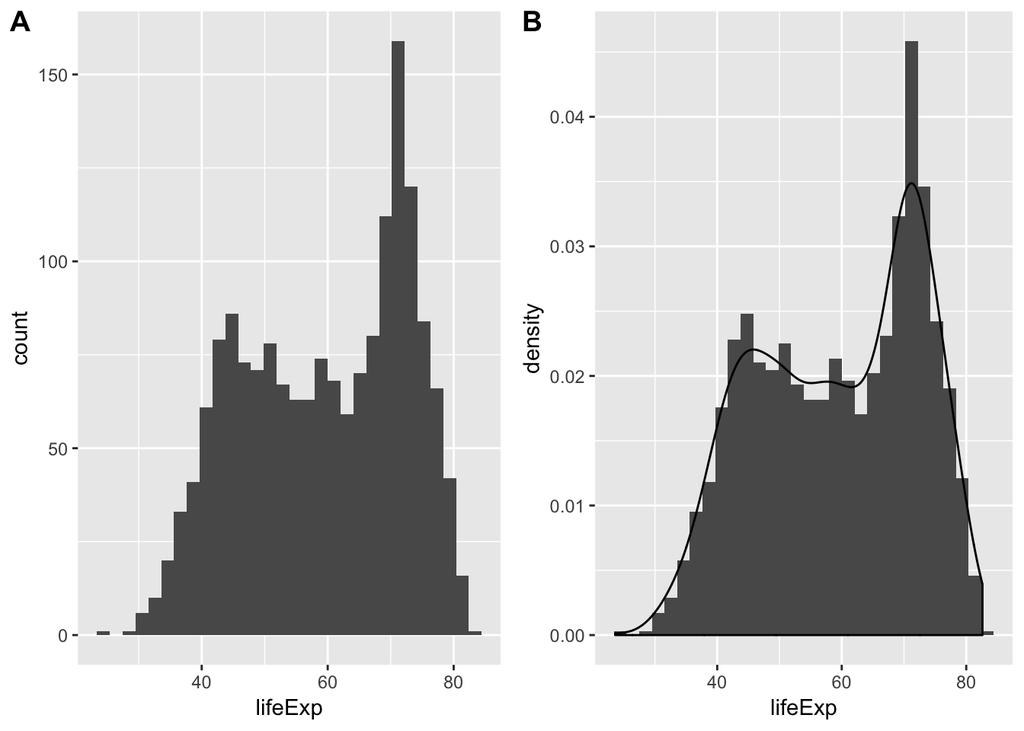

```r
theme_set(theme_gray())
# see the common values of the lifeExp variable using a histogram
g1 = ggplot(gapminder, aes(lifeExp))+
  geom_histogram(bins = 30)

# plot the kernel density
g2 = ggplot(gapminder, aes(lifeExp))+
  geom_histogram(bins= 30,aes(y = ..density..))+
  geom_density()

plot_grid(g1,g2, labels = "AUTO",ncol = 2,scale = c(1.,1.))
```

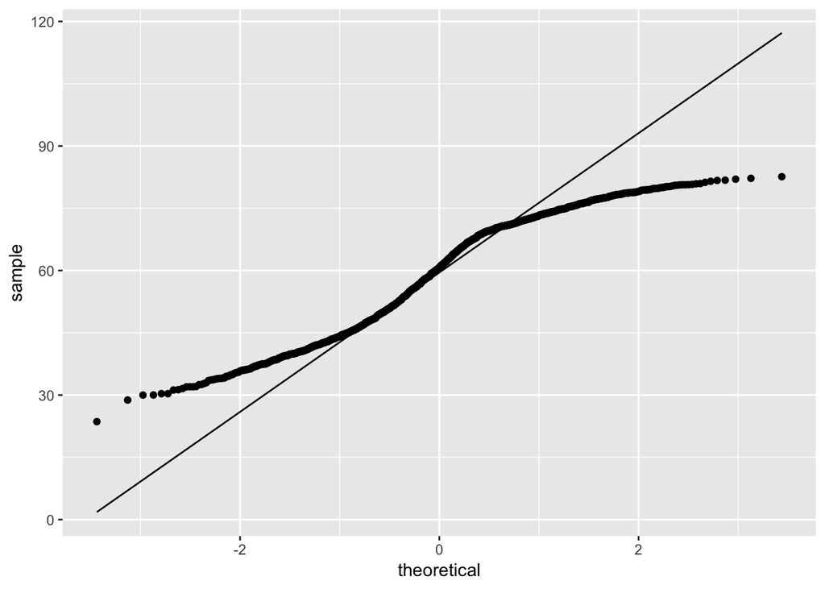

```r
# plot the qq plot
ggplot(gapminder, aes(sample = lifeExp))+
  stat_qq()+stat_qq_line()
```

To illustrate a categorical variable, here I present the barplot, pie chart and a “fresher”" waffle plot of the frequencies of the `continent` variable using the `ggplot2` and `waffle` package for data visualization. To start with, we would like to create a data frame based on the table of `continent` we generated earlier as ggplot takes a data frame as an input. As we can see, after make the table as a data frame, now the continent row we had in the table became a column in our new data frame `df`.

```r
# get the table of continent
attach(gapminder)
# create a data frame
df = data.frame(table(continent))
head(df)
```

```
##   continent Freq
## 1    Africa  624
## 2  Americas  300
## 3      Asia  396
## 4    Europe  360
## 5   Oceania   24
```

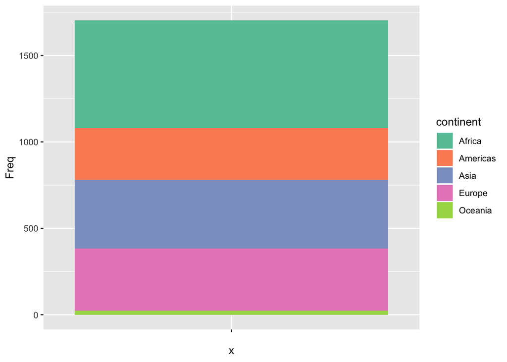

```r
# add more features to the data frame for further use.
df%>%
mutate(prop = scales::percent(Freq/sum(Freq),2)) -> df

bp =
  df %>%
  ggplot(aes(x="", y = Freq, fill = continent))+
  geom_bar(width = 1, stat = "identity")+   # add the barplot
  scale_fill_brewer(palette="Set2")         # use brewer color palettes
# Free to try out Dark2, Pastel2, Set1
# A detailed page of different brewer color palettes is attached in the Reference section.
bp
```

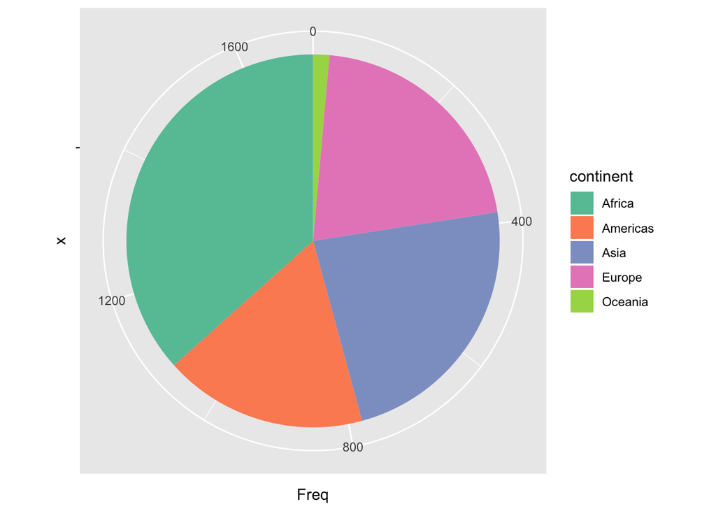

```r
# create the pie chart
pie = bp + coord_polar("y")
pie
```

```r
detach(gapminder)
```

[figure not shown]

```r
# extract the values from df
vals = as.vector(df$Freq)

# create the names of the values
val_names= sprintf("%s (%s)", c("Asia", "Europe", "Africa","Americas", "Oceania "),df$prop)

# name the values using val_names
names(vals) = val_names

# make the waffle plot
waffle::waffle(vals, size = 0.5,rows = 30)
```

### Questions of Interest

Besides seeing how the variables themselves are distributed, our interest also lies on the additional information given by interacting with other information. For example, what if we want to answer the following questions:

*Q1: How the population, variable `pop` is spread out among different continents?*

Boxplot is a easy way to show how a variable distributed by different groups. Based on the boxplots, we can easily see that among the 5 continents, on average, Asian has the highest population but not as high when it comes to GDP per capita. Oceania has the highest GDP per capita on average. And we can also easily detect outlliers and see how spread out the variables are from the boxplot.

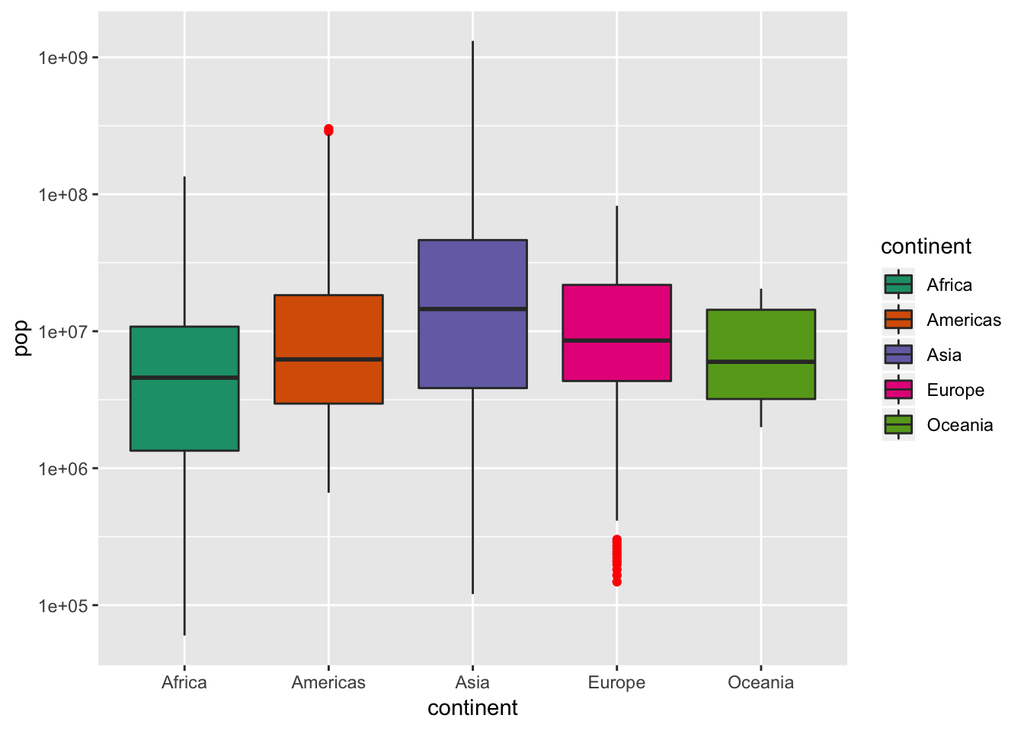

```r
pop_conti = ggplot(gapminder, aes(continent, pop, fill = continent))
pop_conti+
  scale_y_log10()+    # perform the log transformation
  geom_boxplot(outlier.color = "red")+
  scale_fill_brewer(palette="Dark2") # Use the color palette "Dark2"
```

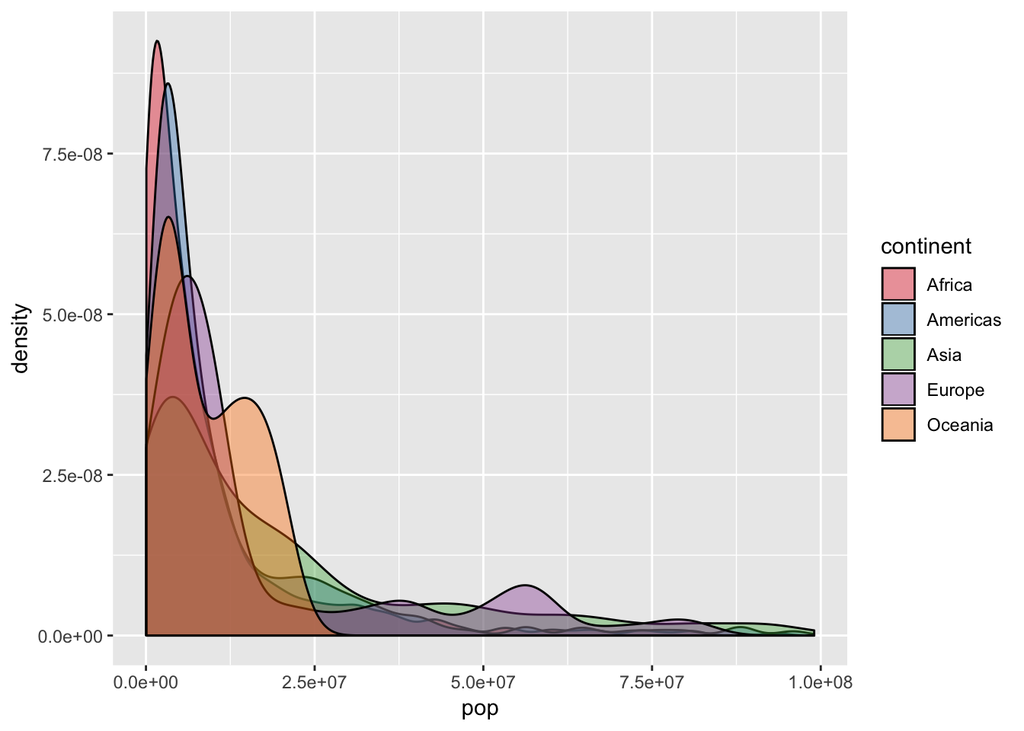

```r
# There are a few outliers that drag the plot wide that we cannot see the details
# Hereby I remove the observations that have pop >1e10^8 and mainly focus on the major data
gapminder %>%
filter(pop<100000000)%>%
ggplot(aes(pop, fill= continent)) +
  geom_density(alpha=0.4)+
  scale_fill_brewer(palette="Set1")
```

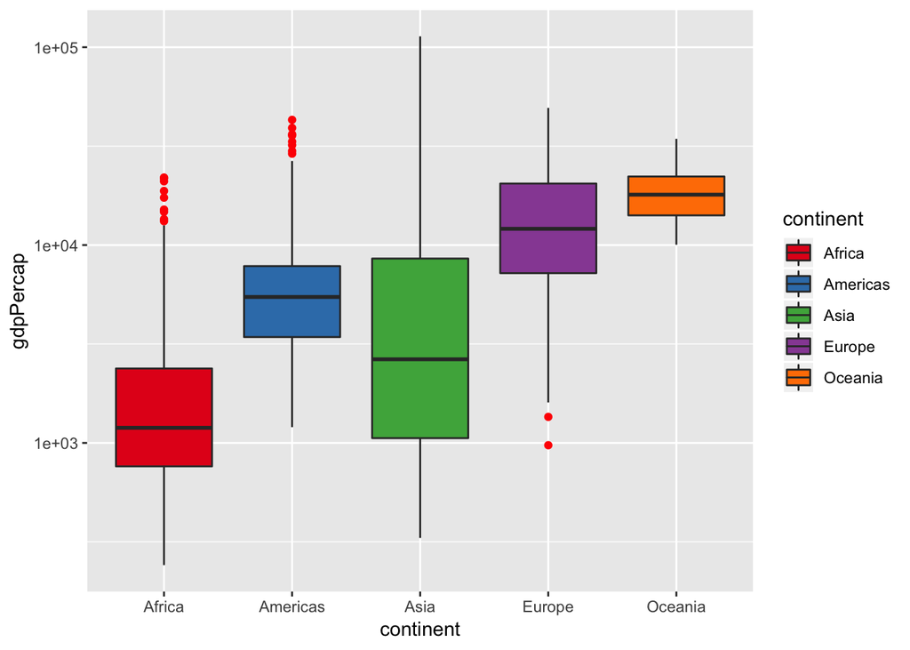

```r
ggplot(gapminder, aes(continent, gdpPercap,fill = continent))+
  scale_y_log10()+
  geom_boxplot(outlier.color = "red")+
  scale_fill_brewer(palette="Set1")
```

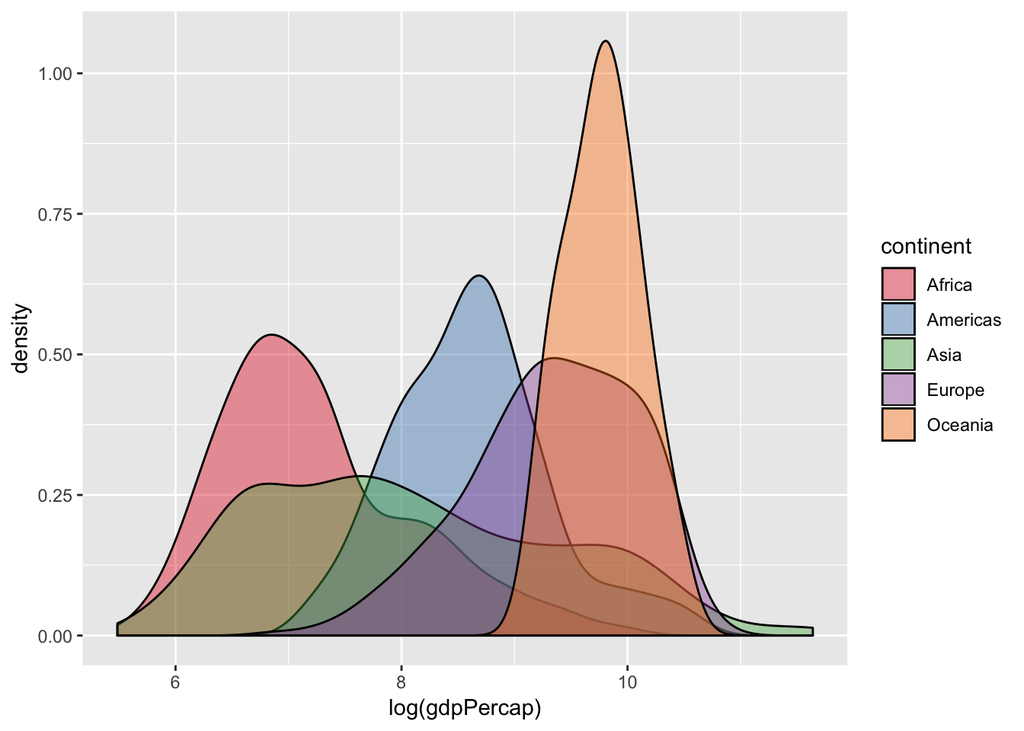

```r
ggplot(gapminder, aes(log(gdpPercap), fill= continent)) +
  geom_density(alpha=0.4)+
  scale_fill_brewer(palette="Set1")
```

Besides boxplots, `ggplot2` also have many other similar tools for such data visualization. Here I present a few examples for further reference:

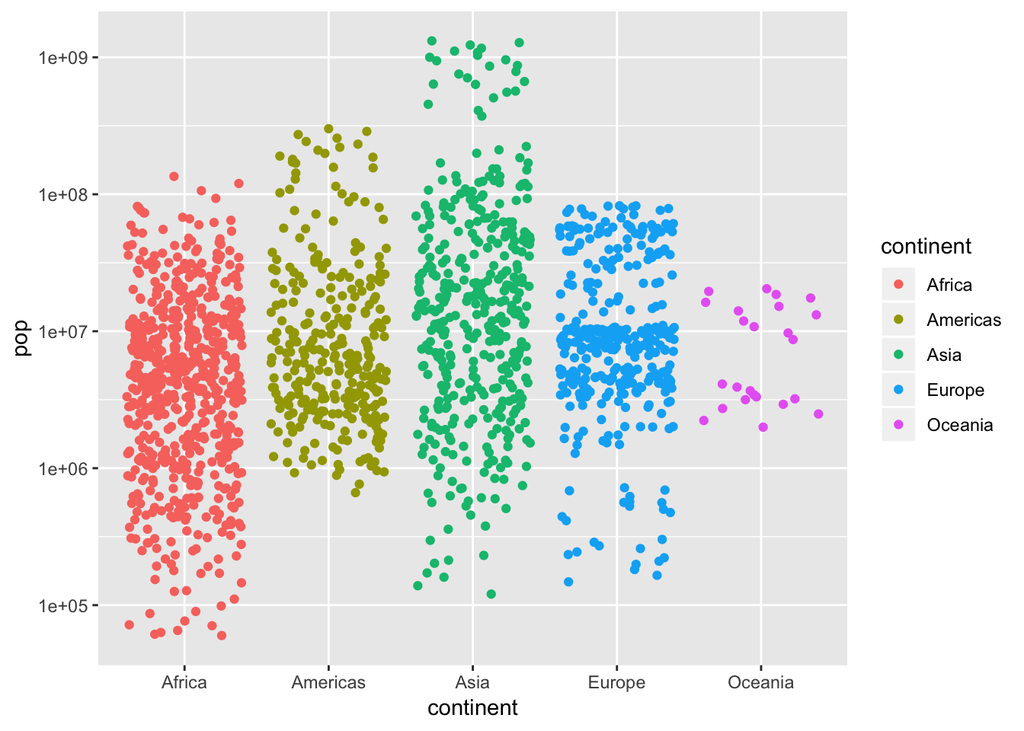

```r
# A jitter plot
gg = ggplot(gapminder, aes(continent, pop, color = continent))+
  scale_y_log10()
gg+geom_jitter()+scale_fill_brewer(palette="Set1")
```

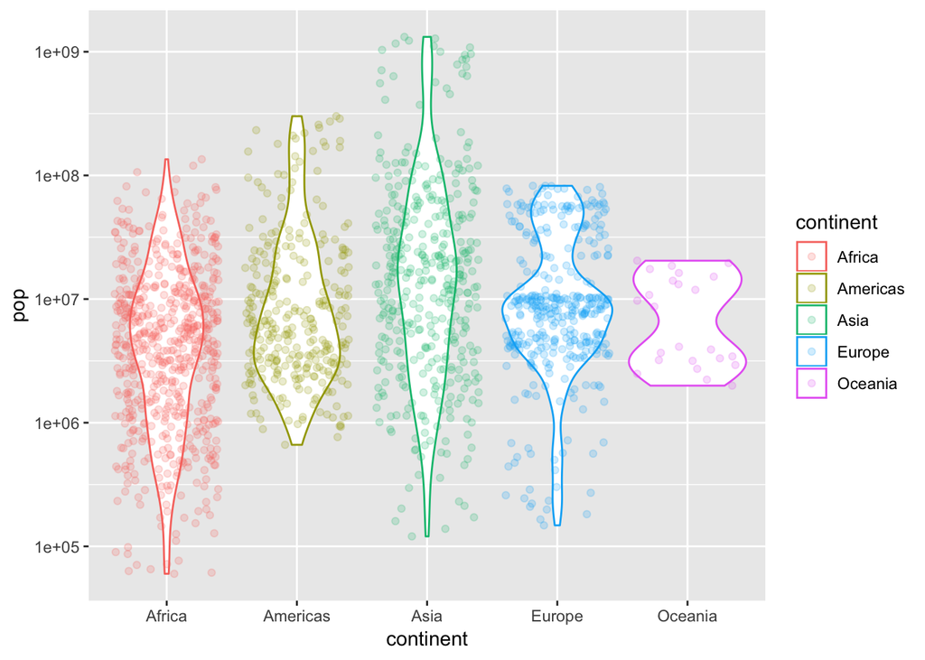

```r
# violin plot along with jitter plot
gg+geom_violin()+geom_jitter(alpha = 0.2)+scale_fill_brewer(palette="Set1")
```

*Q2: Can we get some intuition on how life expectancy is related to the level of wealth?*

Taking the log transformation is commonly used to make the highly skewed distributions less skewed. A comparision of after and before transfromation is shown below. From the less skewed plot we can get the intuition that wealthy areas tend to have higher life expectancy than areas with less wealth.

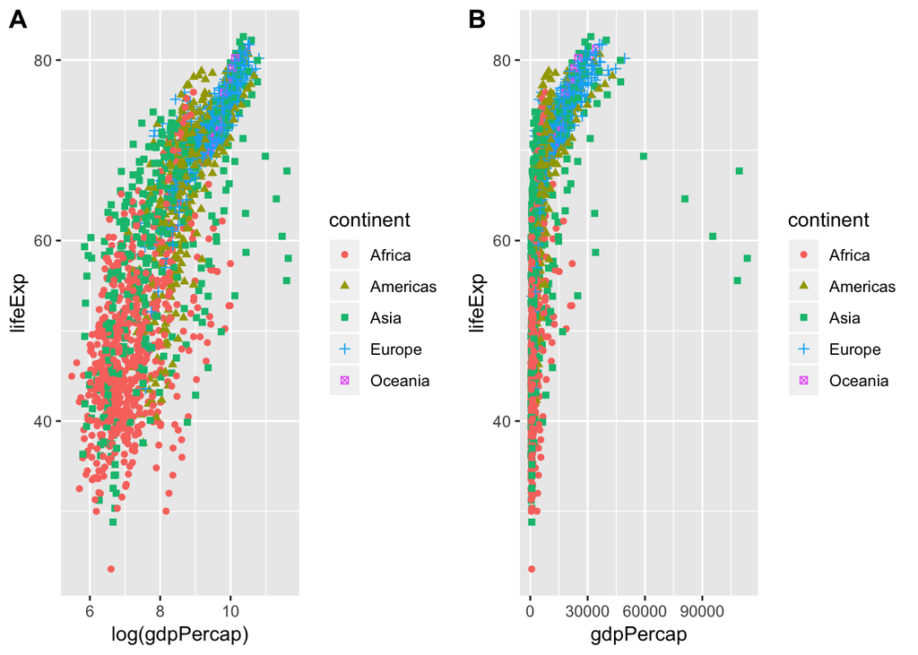

```r
# perform the log transformation of the gdpPercap and create a scatter plot
theme_set(theme_gray())
sc1 = gapminder%>%
  ggplot(aes(log(gdpPercap), lifeExp, color = continent, shape = continent))+
  geom_point()

sc2 = gapminder%>%
  ggplot(aes(gdpPercap, lifeExp, color = continent, shape = continent))+
  geom_point()

# put them side by side
plot_grid(sc1, sc2, labels = "AUTO")
```

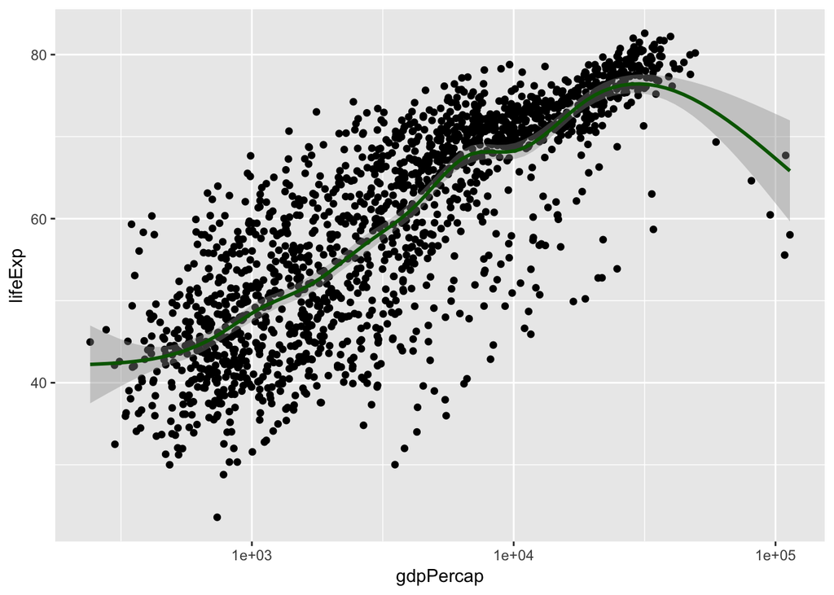

```r
# Add a fitted curve to the points
gapminder %>%
  ggplot(aes(gdpPercap, lifeExp)) +
  scale_x_log10()+
  geom_point() + geom_smooth(color = "darkgreen")
```

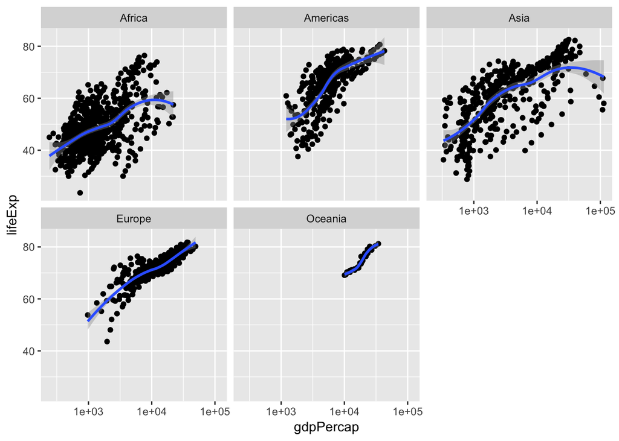

```r
# Faceting
gapminder %>% ggplot(aes(gdpPercap, lifeExp)) + scale_x_log10()+
  geom_point() +
  geom_smooth() +
  facet_wrap(~continent, ncol=3)
```

*Q3: If I want to do some analysis, what about the common assumption of normality?*

Since the `lifeExp` does not comply with normal distribution overall, what if we explore it by the continent? By factoring the qq plot with `continent`, we can see that the `Oceania` seems to be approximately normally distributed.

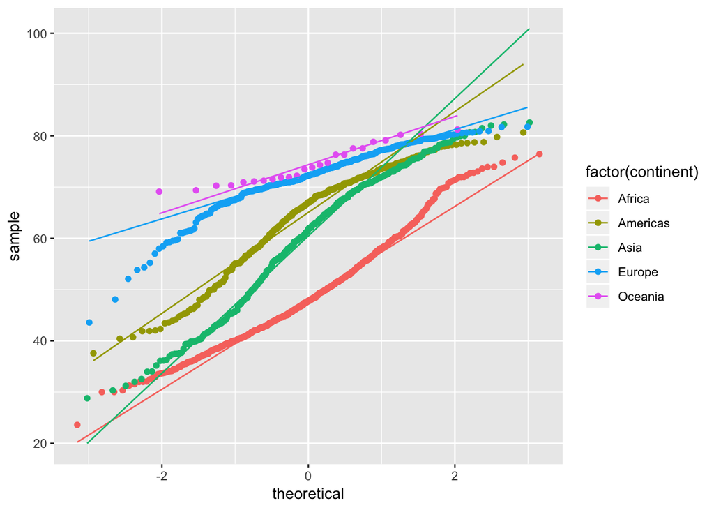

```r
# plot the qqplot factored by different continents
ggplot(gapminder, aes(sample = lifeExp, colour = factor(continent)))+
  stat_qq()+stat_qq_line()
```

*Q4: I am interested in the continent `Oceania`. How can I get a closer look into the `gdpPercap` by year?*

From this plot below we can see the overall trend of the gdpPercap over years along with the individual year distribution of the variable.

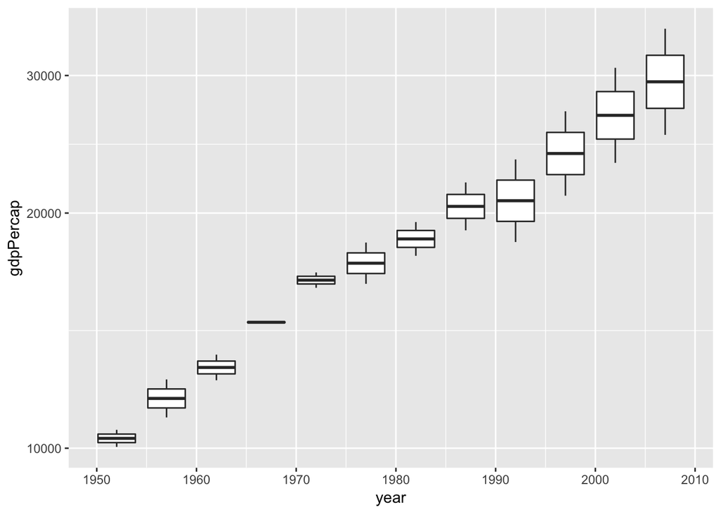

```r
oce = gapminder%>%
  select(continent, year, gdpPercap)%>%   # select only the columns needed
  filter(continent=="Oceania")            # get the data that in the continent Oceania

oce %>%
  ggplot(aes(year, gdpPercap, group = year))+  # group by year
  scale_y_log10()+
  geom_boxplot()
```

*Q5: I am interested in the country `Thailand` and `Vienam`, I would like to see how `lifeExp` and `gdpPercap` spread out with additional information of the population*

With adding the size and color scale based on population, we can easily tell the relative size of the population at each points in the regular scatter plot. It gives us more information in a very straightforward way.

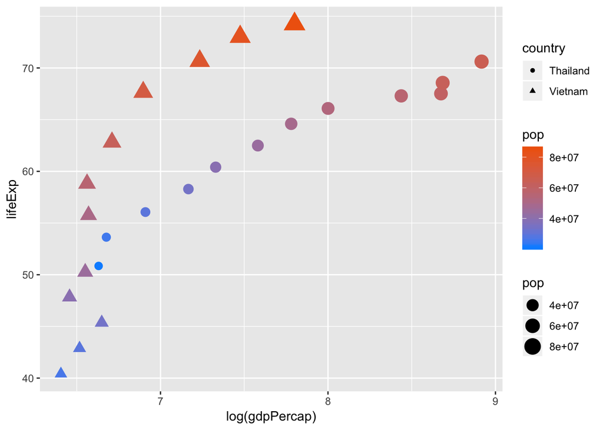

```r
gapminder %>%
  filter(country %in% c("Thailand", "Vietnam"))%>%
  ggplot(aes(log(gdpPercap), lifeExp, shape = country, color = pop))+
  geom_point(aes(size = pop))+ scale_size_area()+
  scale_color_gradient(low = "#0091ff", high = "#f0650e")
```

## Reference and Source.

`gapminder` Data Source: https://www.gapminder.org/data/

Brewer Palettes: http://mkweb.bcgsc.ca/brewer/

## Extra Exercise

From the output we can see that the first version which uses `==` actually runs in R without giving errors. But the result shows that it only gives half of the subset we need. The thing R does by running this code is, it compares the country in the odd number of rows with `"Rwanda"` and even number of rows with `"Afghanistan"`, and generates the output.

The right way to do this is using `%in%` or `|` . Here I present first few rows of the output and you can tell whether they are working or not by looking at the year increments and dimensions.

```r
# "wrong" way of doing it.
tb1 = gapminder%>%
filter(country == c("Rwanda", "Afghanistan"))
dim(tb1)
```

```
## [1] 12  6
```

```r
tb1%>%
  head()%>%
knitr::kable(format = "markdown")
```

| country | continent | year | lifeExp | pop | gdpPercap |
| --- | --- | --- | --- | --- | --- |
| Afghanistan | Asia | 1957 | 30.332 | 9240934 | 820.8530 |
| Afghanistan | Asia | 1967 | 34.020 | 11537966 | 836.1971 |
| Afghanistan | Asia | 1977 | 38.438 | 14880372 | 786.1134 |
| Afghanistan | Asia | 1987 | 40.822 | 13867957 | 852.3959 |
| Afghanistan | Asia | 1997 | 41.763 | 22227415 | 635.3414 |
| Afghanistan | Asia | 2007 | 43.828 | 31889923 | 974.5803 |

```r
# approach 1
tb2 = filter(gapminder, country %in% c("Rwanda", "Afghanistan"))
dim(tb2)
```

```
## [1] 24  6
```

```r
tb2%>%
  head()%>%
knitr::kable(format = "markdown")
```

| country | continent | year | lifeExp | pop | gdpPercap |
| --- | --- | --- | --- | --- | --- |
| Afghanistan | Asia | 1952 | 28.801 | 8425333 | 779.4453 |
| Afghanistan | Asia | 1957 | 30.332 | 9240934 | 820.8530 |
| Afghanistan | Asia | 1962 | 31.997 | 10267083 | 853.1007 |
| Afghanistan | Asia | 1967 | 34.020 | 11537966 | 836.1971 |
| Afghanistan | Asia | 1972 | 36.088 | 13079460 | 739.9811 |
| Afghanistan | Asia | 1977 | 38.438 | 14880372 | 786.1134 |

```r
# approach 2
tb3 = filter(gapminder, country == "Rwanda"| country == "Afghanistan")
dim(tb3)
```

```
## [1] 24  6
```

```r
tb3%>%
  head()%>%
knitr::kable(format = "markdown")
```

| country | continent | year | lifeExp | pop | gdpPercap |
| --- | --- | --- | --- | --- | --- |
| Afghanistan | Asia | 1952 | 28.801 | 8425333 | 779.4453 |
| Afghanistan | Asia | 1957 | 30.332 | 9240934 | 820.8530 |
| Afghanistan | Asia | 1962 | 31.997 | 10267083 | 853.1007 |
| Afghanistan | Asia | 1967 | 34.020 | 11537966 | 836.1971 |
| Afghanistan | Asia | 1972 | 36.088 | 13079460 | 739.9811 |
| Afghanistan | Asia | 1977 | 38.438 | 14880372 | 786.1134 |